# Homework #3 Version 2 Solutions

**See Canvas for the due date**. Complete all of the following problems. Ideally, the theoretical problems should be answered in a Markdown cell directly underneath the question. If you don’t know LaTex/Markdown, you may submit separate handwritten solutions to the theoretical problems. Please do not turn in messy work. Computational problems should be completed in this notebook (using the R kernel is preferred). Computational questions may require code, plots, analysis, interpretation, etc. Working in small groups is allowed, but it is important that you make an effort to master the material and hand in your own work.

## A. Theoretical Problems

### A.1 Deriving the t-statistic

In this question, we’ll walk through the proof that the t-test statistic has a t-distribution. More specifically, consider the simple linear regression model $Y_i = \beta_0 + \beta_1x_i + \varepsilon_i$, where $\varepsilon_i \overset{iid}{\sim} N(0,\sigma^2)$, $x_i$ are fixed and known, $\sigma^2$, $\beta_0$ and $\beta_1$ are fixed and unknown, and $i=1,...,n$. We estimate $\beta_0$ and $\beta_1$ using least squares, and denote the least squares estimators $\widehat\beta_0$ and $\widehat\beta_1$.

Consider testing the hypotheses $H_0: \beta_1 = 0 \,\,\, vs \,\,\, H_1: \beta_1 \ne 0$. In class, we claimed that the appropriate test statistics is

$$\begin{align*}
t = \frac{\widehat\beta_1}{\widehat{s.e.}(\widehat\beta_1)},
\end{align*}$$

where, for simple linear regression,
$$\widehat{s.e.}(\widehat\beta_1) =
\sqrt{\frac{\widehat{\sigma}^2}{\sum^n_{i=1}\left(x_i -
\bar{x}\right)^2}} \,\,\,\, , \text{ and } \,\,\,\,\, \,\,
\widehat{\sigma}^2 = \frac{RSS}{(n - 2)}.$$

Further, we claimed that $t \sim t\left(n - 2 \right)$. That is, the test statistic $t$ has a t-distribution with $n-2$ degrees of freedom. Let’s prove it in a few steps!

**A.1 (a) [4 points] Recall that** $\displaystyle\widehat\beta_1 \sim N\left(\beta_1, \,\, \frac{\sigma^2}{\sum^n_{i=1}\left(x_i - \bar{x}\right)^2} \right)$. Argue that $\displaystyle Z = \frac{\widehat\beta_1}{\sqrt{\frac{\sigma^2}{\sum^n_{i=1}\left(x_i - \bar{x}\right)^2}}}$ has a standard normal distribution under $H_0$. (This should be easy!)

Since $\displaystyle\widehat\beta_1 \sim N\left(\beta_1, \frac{\sigma^2}{\sum^n_{i=1}\left(x_i - \bar{x}\right)^2} \right)$, if we standardize $\widehat\beta_1$, i.e., subtract its mean and divide by its standard deviation, we’ll get standard normal random variable.

For shorthand, let $\mu_{y_i|x_i} = \beta_0 + \beta_1x_i$.

**A.1 (b) (i). [5 points] First, show that** $\displaystyle \frac{\sum^n_{i=1}\left(y_i - \mu_{y_i|x_i}\right)^2}{\sigma^2} \sim \chi^2(n)$. This should follow straight from the definition of the $\chi^2(n)$ distribution given in class, along with some easy algebra!

$Y_i \overset{iid}{\sim} N(\mu_{y_i|x_i}, \, \sigma^2)$ implies that $\left(\frac{y_i - \mu_{y_i|x_i}}{\sigma}\right) \sim N(0,1)$. So, by definition of $\chi^2(n)$,

$\displaystyle \frac{\sum^n_{i=1}\left(y_i - \mu_{y_i|x_i}\right)^2}{\sigma^2} = \sum^n_{i=1}\left(\frac{y_i - \mu_{y_i|x_i}}{\sigma}\right)^2 \sim \chi^2(n)$, since $\left(\frac{y_i - \mu_{y_i|x_i}}{\sigma}\right)$ is standard normal.

**A.1 (b) (ii). [8 points] Now, show that** $\displaystyle \frac{\sum^n_{i=1}\left(y_i - \mu_{y_i|x_i}\right)^2}{\sigma^2} = \frac{\sum^n_{i=1}\left(y_i - \widehat{y}_i\right)^2}{\sigma^2} + \frac{\sum^n_{i=1}\left(\widehat{y}_i - \mu_{y_i|x_i}\right)^2}{\sigma^2}$. (HINT: add and subtract $\widehat{y}_i$ to the lefthand side.)

Note that the middle term $\frac{\sum^n_{i=1}\left(y_i - \widehat{y}_i\right)^2}{\sigma^2}$ can be written as $\frac{RSS}{\sigma^2}$, or equivalently, $\frac{(n-2)\widehat\sigma^2}{\sigma^2}.$

$$\begin{align}
\displaystyle \frac{\sum^n_{i=1}\left(y_i -
\mu_{y|x}\right)^2}{\sigma^2} &= \frac{\sum^n_{i=1}\left(y_i -
\widehat{y}_i +\widehat{y}_i - \mu_{y|x}\right)^2}{\sigma^2} =
\frac{\sum^n_{i=1}\left(y_i - \widehat{y}_i\right)^2}{\sigma^2} +
\frac{\sum^n_{i=1}\left(\widehat{y}_i - \mu_{y|x}\right)^2}{\sigma^2} +
2\frac{\sum^n_{i=1}\left( y_i - \widehat{y}_i\right)\left(\widehat{y}_i
- \mu_{y|x} \right)}{\sigma^2} \\
&=\frac{\sum^n_{i=1}\left(y_i - \widehat{y}_i\right)^2}{\sigma^2} +
\frac{\sum^n_{i=1}\left(\widehat{y}_i - \mu_{y|x}\right)^2}{\sigma^2},
\end{align}$$

because $\displaystyle\frac{\sum^n_{i=1}\left( y_i - \widehat{y}_i\right)\left(\widehat{y}_i - \mu_{y|x} \right)}{\sigma^2} = \frac{\sum^n_{i=1}\left( y_i - \widehat{y}_i\right)\widehat{y}_i - \sum^n_{i=1}\left( y_i - \widehat{y}_i\right) \mu_{y|x}}{\sigma^2} = 0$

Ok, so maybe we won’t do the *entire* proof. Note, without having to prove it, that $\displaystyle\frac{(n-2)\widehat\sigma^2}{\sigma^2} \sim \chi^2(n-2)$. This is because

$$\displaystyle
\underbrace{\frac{\sum^n_{i=1}\left(y_i -
\mu_{y|x}\right)^2}{\sigma^2}}_{\chi^2(n)} =
\underbrace{\frac{(n-2)\widehat\sigma^2}{\sigma^2}}_{\chi^2(n - 2)} +
\underbrace{\frac{\sum^n_{i=1}\left(\widehat{y}_i -
\mu_{y|x}\right)^2}{\sigma^2}}_{\chi^2(2)},$$

which follows from some facts about the $\chi^2$ distribution involving moment generating functions. Math Stat students, you should know how to prove this :)

With $\displaystyle\frac{(n-2)\widehat\sigma^2}{\sigma^2} \sim \chi^2(n-2)$ in hand, let’s finish the proof that our test statistic for individual t-tests follows a t distribution with $n-2$ degrees of freedom.

By definition, a random variable $T$ has a t-distribution with $d$ degrees of freedom if it can be written as

$$T =
\frac{Z}{\sqrt{W\big/d}},$$

where $Z \sim N(0,1)$ and $W \sim \chi^2(d)$.

**A.1 (c) [8 points] Prove that** $t = \frac{\widehat\beta_1}{\widehat{s.e.}(\widehat\beta_1)}$ can be written in the form of a t-distributed random variable with $n-2$ degrees of freedom. Specifically, let $Z$ be defined as in problem A.1 (a), and $W = \frac{(n-2)\widehat\sigma^2}{\sigma^2}$. Show that

$$\begin{align*}
\frac{Z}{\sqrt{W\big/(n-2)}} =
\frac{\widehat\beta_1}{\widehat{s.e.}(\widehat\beta_1)} = t ,
\end{align*}$$

which, by definition, means that $t \sim t(n-2)$.

First note that $W\big/(n-2) = \frac{\widehat\sigma^2}{\sigma^2}$. Then:

$$\begin{align*}
\frac{Z}{\sqrt{W\big/(n-2)}} &=
\frac{\widehat\beta_1\bigg/\sqrt{\frac{\sigma^2}{ \sum^n_{i=1}\left(x_i
- \bar{x} \right)^2}}}{\sqrt{\frac{\widehat\sigma^2}{\sigma^2}}} =
\frac{\widehat\beta_1}{\sqrt{\left(\frac{\sigma^2}{\sum^n_{i=1}\left(x_i
- \bar{x}\right)^2}\right) \left(\frac{\widehat\sigma^2}{\sigma^2}
\right)} } \\
&=\frac{\widehat\beta_1}{\sqrt{\frac{\widehat\sigma^2}{
\sum^n_{i=1}\left(x_i - \bar{x} \right)^2}} } =
\frac{\widehat\beta_1}{\widehat{s.e.}(\widehat\beta_1)} = t \sim t(n-2).
\end{align*}$$

### Problem A.2

*Over the next few classes, we will be discussing the use of regression–and statistical modeling more generally–for prediction and explanation. The purpose of this problem is to encourage you to gain a deeper understanding of prediction, explanation, and the relationship between these two concepts.*

**[10 points] Read “To Explain or to Predict?” by Galit Shmueli and answer at least three of the following questions. Each answer should be typed in a markdown cell in this notebook, and roughly one paragraph (5-10 sentences) in length. The goal of this assignment is to provide the opportunity to think more rigorously about some of the statistical models that we will encounter in this course. What is their purpose? How can we get the most out of our statistical analysis?**

1. What is explanatory modeling? Where is explanatory modeling most often used? What does explanatory modeling have to do with causality?
2. What is predictive modeling? Where is predictive modeling most often used? What does predictive modeling have to do with causality?
3. How are explanation and prediction different? Is it universally recognized that they are different?
4. Describe how, according to Shmueli, the statistical modeling procedure might change based on whether the goal of the modeling is explanation or prediction.
5. What are some suggestions that Shmueli gives to the statistical community based on his analysis of prediction and explanation? Do you agree with these suggestions?

(If you did this as your “classwork #0” assignment, then, lucky you! Review and past your answers here.)

Answers will vary…

### A.3 More linear algebra and regression!

In class, we defined the *hat* or *projection* matrix as

$$H = X(X^TX)^{-1}X^T.$$

The goal of this question is to use the hat matrix to prove that the fitted values, $\widehat{\mathbf Y}$, and the residuals, $\widehat{\boldsymbol\varepsilon}$, are uncorrelated. We will do it in steps, and *some* of the proofs will only be required for STAT 5010 students. Note that STAT 4010 students are asked to answer part (e), as to why this result has practical importance.

**A.3 (a) [5 points] Show that** $\widehat{Y} = HY$. That is, $H$ “puts a hat on” $Y$.

$\widehat{Y} = X\widehat{\boldsymbol\beta} = X(X^TX)^{-1}X^T\mathbf{Y} = H\mathbf{Y}$

**A.3 (b) [5 points] Show that** $H$ is symmetric: $H = H^T$.

$H^T = \big(X(X^TX)^{-1}X^T \big)^T = (X^T)^T\big[(X^TX)^{-1}\big]^TX^T = X\big[(X^TX)^{T}\big]^{-1}X^T = X(X^TX)^{-1}X^T = H$

**A.3 (c) [4 points] Show that** $H(I_n - H) = 0_n$, where $0_n$ is the zero matrix of size $n \times n$.

Note that

$$HH
= \bigg(X(X^TX)^{-1}X^T\bigg)\bigg(X(X^TX)^{-1}X^T\bigg) =
X(X^TX)^{-1}X^TX(X^TX)^{-1}X^T = X(X^TX)^{-1}X^T = H,$$
because $(X^TX)^{-1}X^TX = I_{p+1}$.

Thus, $H(I_n - H) = HI_n - HH = H - H = 0_n$

**A.3 (d) [4 points] Stating that** $\widehat{\mathbf Y}$ is uncorrelated with $\widehat{\boldsymbol\varepsilon}$ is equivalent to showing that these vectors are orthogonal. That is, we need to show that their dot product is zero:

$$\widehat{\mathbf
Y}^T\widehat{\boldsymbol\varepsilon} = 0.$$
**Prove this result.**

It’s intersting to think about why uncorrelated, in this case, is equivalent to orthogonal. Extra credit if you can tell me why!

$$\widehat{\mathbf
Y}^T\widehat{\boldsymbol\varepsilon} = (H\mathbf Y)^T(I-H)\mathbf Y =
\mathbf Y^TH^T(I_n-H)Y = \mathbf Y^TH(I_n-H)Y = \mathbf Y^T0_nY =
0.$$

**A.3 (e) [2 points] Why is this result important in the practical use of linear regression?**

This result shows that, if the linear regression assumptions are met, then there should be no correlation between the fitted values, $\widehat{\mathbf{Y}}$, and the residuals, $\widehat{\boldsymbol\varepsilon}$. Thus, it may give us a way to check some of our model assumptions. For example, if we plot the residuals against the fitted values and see a trend, we might conclude that some model assumption is incorrect (we will learn more about “regression diagnostics” in a later unit).

### Problem A.4 Trace of the hat matrix

Define the trace of a square matrix

$A = \left(\begin{matrix} a_{1,1} & a_{1,2} & \cdots & a_{1,n} \\ a_{2,1} & a_{2,2} & \cdots & a_{2,n} \\ \vdots & \vdots & \ddots & \vdots \\ a_{n,1} & a_{n,2} & \cdots & a_{n,n} \end{matrix} \right)$

to be $tr(A) = \sum^n_{i=1}a_{i,i}$, i.e., the sum of the diagonal elements of $A$.

**A.4 (a) [6 points] Let** $B$ be a $m \times n$ matrix and $C$ $n\times m$ matrix. Prove that $tr(BC) = tr(CB).$

$$\begin{align*}
tr(BC) &= \left(b_{1,1}c_{1,1} + b_{1,2}c_{2,1} + ... +
b_{1,n}c_{n,1}\right) + \left(b_{2,1}c_{1,2} + b_{2,2}c_{2,2} + ... +
b_{2,n}c_{n,2}\right) + ... + \left(b_{m,1}c_{1,m} + b_{m,2}c_{2,m} +
... + b_{m,n}c_{n,m}\right) \\
&= \sum^m_{i=1}\left(b_{i,1}c_{1,i} + b_{i,2}c_{2,i} + ... +
b_{i,n}c_{n,i}\right) \\
&= \sum^m_{i=1}\sum^n_{j=1} b_{i,j}c_{j,i} \\
&= \sum^n_{j=1}\sum^m_{i=1}c_{j,i} b_{i,j} \\
&= \sum^n_{i=j}\left(c_{j,1}b_{1,j} + c_{j,2}b_{2,j} + ... +
c_{j,m}b_{m,j}\right) \\
&= \left(c_{1,1}b_{1,1} + c_{1,2}b_{2,1} + ... +
c_{1,m}b_{m,1}\right) + \left(c_{2,1}b_{1,2} + c_{2,2}b_{2,2} + ... +
c_{2,m}b_{m,2}\right) + ... + \left(c_{n,1}b_{1,n} + c_{n,2}b_{2,n} +
... + c_{n,m}b_{m,n}\right) \\
&=tr(CB)
\end{align*}$$

(OK, that’s awesome!)

**A.4 (b) [4 points] Let** $H$ be the hat matrix as defined in class. Prove that $tr(H) = p+1$, where $p$ is the number of parameters in the regression.

$\displaystyle tr\left( H \right) = tr\left( \underbrace{X\left(X^TX\right)^{-1}}_{n\times (p+1)} \, \underbrace{X^T}_{(p+1) \times n} \right) = tr\left( \underbrace{X^T}_{(p+1) \times n}\underbrace{X\left(X^TX\right)^{-1}}_{n\times (p+1)} \right) = tr\left(I_{p+1}\right) = p+1$

## B. Computational Problems

## Problem B.1: Comparing Models (20 points)

In this exercise, we will fit multiple different models to the same data and determine which of those models we should ultimately use.

This data set has $345$ rows and $7$ columns, where the 7th column is not a variable but just a train/test selector. The dataset does not contain any variable representing presence or absence of a liver disorder.

1. `Mcv`: Mean Corpuscular Volume (Blood Test)
2. `Alkphos`: Alkaline Phosphotase (Blood Test)
3. `Sgpt`: Alamine Aminotransferase (Blood Test)
4. `Sgot`: Aspartate Aminotransferase (Blood Test)
5. `Gammagt`: Gamma-Glutamyl Transpeptidase (Blood Test)
6. `Drinks`: Number of half-pint equivalents of alcoholic beverages drunk per day

The first five columns are integer-valued and represent the result of various blood tests which may be of use in diagnosing alcohol-related liver disorders. The sixth column is real-valued and represents the number of alcoholic drinks (equivalent to half pints of beer) taken per day by the subject, self reported.

```r
library(ggplot2)

liver = na.omit(read.csv(url("https://raw.githubusercontent.com/CUBuffs/Statistical-Learning-/main/Modern%20Regression%20Analysis/Datasets/liver.csv")))

liver = liver[,1:6]

summary(liver)
```

```
##       Mcv            Alkphos            Sgpt             Sgot
##  Min.   : 65.00   Min.   : 23.00   Min.   :  4.00   Min.   : 5.00
##  1st Qu.: 87.00   1st Qu.: 57.00   1st Qu.: 19.00   1st Qu.:19.00
##  Median : 90.00   Median : 67.00   Median : 26.00   Median :23.00
##  Mean   : 90.16   Mean   : 69.87   Mean   : 30.41   Mean   :24.64
##  3rd Qu.: 93.00   3rd Qu.: 80.00   3rd Qu.: 34.00   3rd Qu.:27.00
##  Max.   :103.00   Max.   :138.00   Max.   :155.00   Max.   :82.00
##     Gammagt           Drinks
##  Min.   :  5.00   Min.   : 0.000
##  1st Qu.: 15.00   1st Qu.: 0.500
##  Median : 25.00   Median : 3.000
##  Mean   : 38.28   Mean   : 3.455
##  3rd Qu.: 46.00   3rd Qu.: 6.000
##  Max.   :297.00   Max.   :20.000
```

#### B.1 (a) [6 points] Three Different Models

We will fit three different models to this data:

1. `mod.1`: Fits `Drinks` as the response with `Mcv` as the predictor.
2. `mod.2`: Fits `Drinks` as the response with `Mcv` and `Alkphos` as predictors.
3. `mod.3`: Fits `Drinks` as the response with `Mcv`, `Alkphos` and `Sgpt` as predictors.

Fit these models in the cell below.

```r
### BEGIN SOLUTION HERE
mod.1 = lm(Drinks ~ Mcv, data= liver)
summary(mod.1)
```

```
##
## Call:
## lm(formula = Drinks ~ Mcv, data = liver)
##
## Residuals:
##     Min      1Q  Median      3Q     Max
## -5.4986 -2.4484 -0.5294  1.5823 15.6438
##
## Coefficients:
##              Estimate Std. Error t value Pr(>|t|)
## (Intercept) -17.69936    3.47408  -5.095 5.78e-07 ***
## Mcv           0.23463    0.03849   6.097 2.92e-09 ***
## ---
## Signif. codes:  0 '***' 0.001 '**' 0.01 '*' 0.05 '.' 0.1 ' ' 1
##
## Residual standard error: 3.175 on 343 degrees of freedom
## Multiple R-squared:  0.09777,    Adjusted R-squared:  0.09514
## F-statistic: 37.17 on 1 and 343 DF,  p-value: 2.917e-09
```

```r
mod.2 = lm(Drinks ~ Mcv + Alkphos, data=liver)
summary(mod.2)
```

```
##
## Call:
## lm(formula = Drinks ~ Mcv + Alkphos, data = liver)
##
## Residuals:
##     Min      1Q  Median      3Q     Max
## -5.5122 -2.4579 -0.4898  1.8083 15.4466
##
## Coefficients:
##               Estimate Std. Error t value Pr(>|t|)
## (Intercept) -18.547315   3.500110  -5.299 2.09e-07 ***
## Mcv           0.231749   0.038417   6.032 4.19e-09 ***
## Alkphos       0.015859   0.009314   1.703   0.0895 .
## ---
## Signif. codes:  0 '***' 0.001 '**' 0.01 '*' 0.05 '.' 0.1 ' ' 1
##
## Residual standard error: 3.166 on 342 degrees of freedom
## Multiple R-squared:  0.1054, Adjusted R-squared:  0.1001
## F-statistic: 20.14 on 2 and 342 DF,  p-value: 5.4e-09
```

```r
mod.3 = lm(Drinks ~ Mcv + Alkphos + Sgpt, data=liver)
summary(mod.3)
```

```
##
## Call:
## lm(formula = Drinks ~ Mcv + Alkphos + Sgpt, data = liver)
##
## Residuals:
##     Min      1Q  Median      3Q     Max
## -7.8892 -2.4654 -0.4542  1.7629 14.1647
##
## Coefficients:
##               Estimate Std. Error t value Pr(>|t|)
## (Intercept) -17.678478   3.468131  -5.097 5.72e-07 ***
## Mcv           0.214513   0.038347   5.594 4.56e-08 ***
## Alkphos       0.013841   0.009221   1.501  0.13428
## Sgpt          0.027170   0.008759   3.102  0.00208 **
## ---
## Signif. codes:  0 '***' 0.001 '**' 0.01 '*' 0.05 '.' 0.1 ' ' 1
##
## Residual standard error: 3.127 on 341 degrees of freedom
## Multiple R-squared:  0.1299, Adjusted R-squared:  0.1223
## F-statistic: 16.97 on 3 and 341 DF,  p-value: 2.693e-10
```

```r
### END SOLUTION HERE
```

**B.1 (b) [3 points] Partial F-Tests**

Compare the 3 models using pairwise F-tests to determine which of the three we should use moving forward. It may be helpful to write out the null and alternative hypotheses for these tests.

Copy your selected model into the `final.model` variable.

```r
final.model = NA
### BEGIN SOLUTION HERE
anova(mod.1, mod.2)
```

```
## Analysis of Variance Table
##
## Model 1: Drinks ~ Mcv
## Model 2: Drinks ~ Mcv + Alkphos
##   Res.Df    RSS Df Sum of Sq      F  Pr(>F)
## 1    343 3457.9
## 2    342 3428.8  1    29.069 2.8995 0.08952 .
## ---
## Signif. codes:  0 '***' 0.001 '**' 0.01 '*' 0.05 '.' 0.1 ' ' 1
```

```r
# We fail to reject the null for the first test, so we stick with mod.1

anova(mod.1, mod.3)
```

```
## Analysis of Variance Table
##
## Model 1: Drinks ~ Mcv
## Model 2: Drinks ~ Mcv + Alkphos + Sgpt
##   Res.Df    RSS Df Sum of Sq      F   Pr(>F)
## 1    343 3457.9
## 2    341 3334.7  2    123.17 6.2977 0.002062 **
## ---
## Signif. codes:  0 '***' 0.001 '**' 0.01 '*' 0.05 '.' 0.1 ' ' 1
```

```r
# We reject the null, so mod.3 is statistically significantly better than mod.1.

final.model = mod.3
### END SOLUTION HERE
```

| Res.Df | RSS | Df | Sum of Sq | F | Pr(>F) |
| --- | --- | --- | --- | --- | --- |
| 343 | 3457.850 | NA | NA | NA | NA |
| 342 | 3428.781 | 1 | 29.06911 | 2.899466 | 0.08951748 |

| Res.Df | RSS | Df | Sum of Sq | F | Pr(>F) |
| --- | --- | --- | --- | --- | --- |
| 343 | 3457.850 | NA | NA | NA | NA |
| 341 | 3334.679 | 2 | 123.1718 | 6.297694 | 0.002061806 |

**B.1 (c) [4 points] Coefficient Confidence Intervals**

Using your selected best model, calculate a $95\%$ confidence interval for the parameter associated with the `Mcv` predictor (you can use the `confint()` function). Save the lower and upper values into `Mcv.CI.lower` and `Mcv.CI.upper` respectively.

```r
Mcv.CI.lower = NA
Mcv.CI.upper = NA

### BEGIN SOLUTION HERE
CI = confint(mod.3, parm="Mcv", level=0.95)
Mcv.CI.lower = CI[1, 1]
Mcv.CI.upper = CI[1, 2]
CI
```

```
##         2.5 %    97.5 %
## Mcv 0.1390871 0.2899383
```

```r
### END SOLUTION HERE
```

|  | 2.5 % | 97.5 % |
| --- | --- | --- |
| Mcv | 0.1390871 | 0.2899383 |

**B.1 (d) [6 points] Model Comparison**

So far, we’ve used the F-test as a way to choose a “best” model among the three proposed. Now let’s compare the models according to their mean squared errors (MSE). The MSE is defined as

$$\begin{align*}
MSE = \frac{1}{n}\sum^n_{i=1}\left(y_i - \widehat{y}_i \right)^2.
\end{align*}$$

Compute the MSE for each of the three models and save their values into their respective `MSE.#` variables.

Which of these models has the best MSE? Do these conclusions agree with the model you selected in part **1.b**? Think about why or why not.

```r
MSE.1 = NA
MSE.2 = NA
MSE.3 = NA

### BEGIN SOLUTION HERE
calc_MSE = function(model, n){
    MSE = 1/n * sum((resid(model))^2)
    return(MSE)
}
n = length(liver$Drink)
MSE.1 = calc_MSE(mod.1, n)
MSE.2 = calc_MSE(mod.2, n)
MSE.3 = calc_MSE(mod.3, n)

MSE.1
```

```
## [1] 10.02276
```

```r
MSE.2
```

```
## [1] 9.938497
```

```r
MSE.3
```

```
## [1] 9.665735
```

```r
### END SOLUTION HERE
```

10.0227550396597

9.9384967553223

9.66573543837266

The third model, i.e., the full model, has the best MSE, because the RSS will always be lower as we add predictors to our model.

**B.1 (e) This model violates at least one of our regression assumptions. Which one? Produce a plot to show evidence of this violation.**

This model violates the assumption that the response is (roughly) normal. It is a count, not a continuous variable.

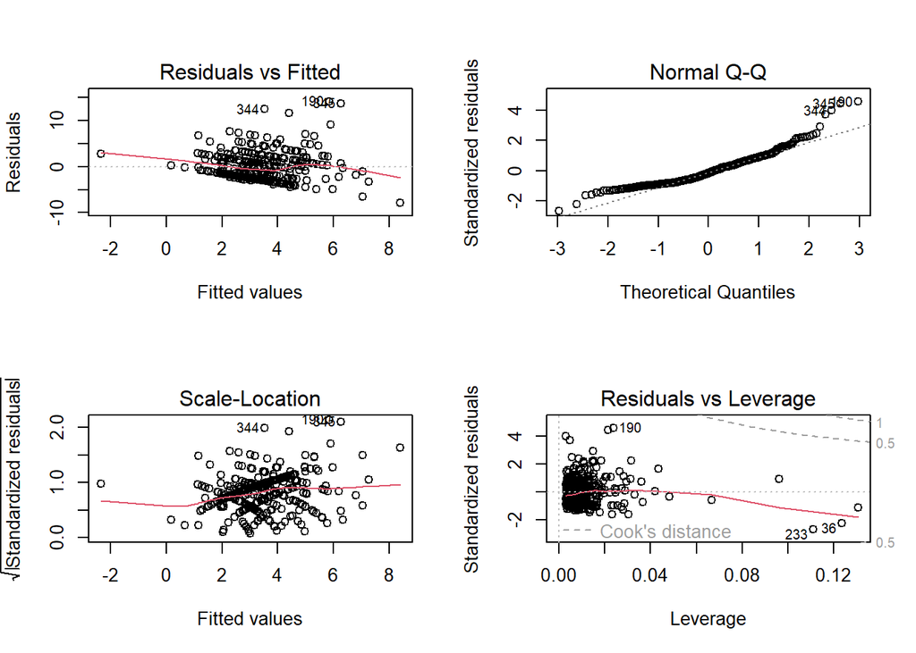

```r
par(mfrow = c(2,2))
plot(mod.3)
```

### Problem B.2

Consider the [`teengamb`](https://rdrr.io/cran/faraway/man/teengamb.html) data. Fit a model with `gamble` as the response and `income` as the predictor.

**B.2 (a) [2 points] Load the dataset and explore it graphically and numerically. Are there relationships between variables?**

```r
df = read.csv("https://raw.githubusercontent.com/CUBuffs/Statistical-Learning-/main/Modern%20Regression%20Analysis/Datasets/teengamb.txt", sep = "\t")
```

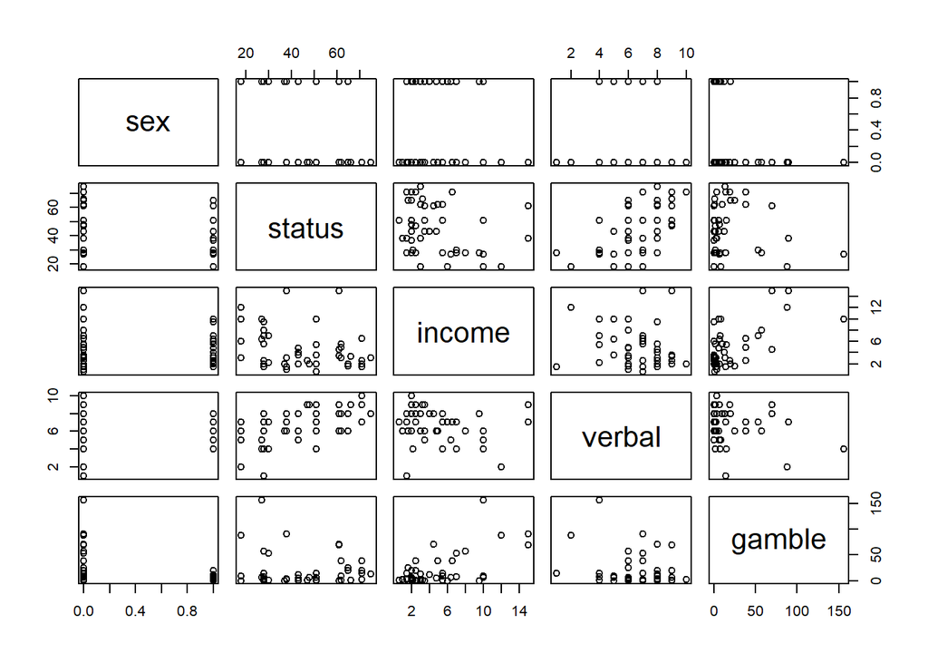

```r
pairs(df)
```

**B.2 (b) [3 points] Randomly split the dataset into two parts:**

1. **50% of the data stored in the variable `train`. This will be the data that we fit/train our model on.**
2. **the remaining 50% of the data stored in the variable `test`. We will use this data to test our predictions.**

```r
set.seed(1985) #don't change the seed!
### BEGIN SOLUTION HERE
n = floor(0.5 * nrow(df))
index = sample(seq_len(nrow(df)), size = n)
train = df[index, ]
test = df[-index, ]

### END SOLUTION HERE
```

**B.2 (c) [2 points] Conduct simple linear regression, using the `lm_gamble = lm()` function and your training set, `train`, with{ `gamlbe` as the response, and `income` as the predictor.**

```r
lm_gamble = lm(gamble ~ income, data = train)
summary(lm_gamble)
```

```
##
## Call:
## lm(formula = gamble ~ income, data = train)
##
## Residuals:
##     Min      1Q  Median      3Q     Max
## -29.385  -8.506  -5.722   8.299  55.224
##
## Coefficients:
##             Estimate Std. Error t value Pr(>|t|)
## (Intercept)    1.539      6.532   0.236   0.8160
## income         2.942      1.142   2.577   0.0176 *
## ---
## Signif. codes:  0 '***' 0.001 '**' 0.01 '*' 0.05 '.' 0.1 ' ' 1
##
## Residual standard error: 19.72 on 21 degrees of freedom
## Multiple R-squared:  0.2402, Adjusted R-squared:  0.204
## F-statistic:  6.64 on 1 and 21 DF,  p-value: 0.01759
```

**B.2 (d) [8 points] We learned that, often, the goal of regression is to make predictions on new data. Let’s see how well the model does at predicting values that we left out of the training set.**

**We can get a sense of how well the model does at predicting by computing the mean squared prediction error (MSPE):**

$$\begin{align*}
MSPE = \frac{1}{k}\sum^k_{i=1}\left(y^\star_i - \widehat{y}^\star_i
\right)^2 = \frac{1}{k}\sum^k_{i=1}\left(y^\star_i -
\mathbf{x}^\star_i\boldsymbol{\widehat\beta} \right)^2
\end{align*}$$

where:

- $k$ is the number of rows in the `test` set.
- $y^\star_i$ is the $i^{th}$ response value in the `test` set.
- $\mathbf{x}_i^\star = \left(1,x_{i,1}^\star, x_{i,2}^\star,...,x_{i,p}^\star \right)$ is the $i^{th}$ set of predictors (and a 1 for the intercept multiplication…) in the `test` set. Notice that it’s a row vector.
- $\widehat{\boldsymbol\beta}$ is the least squares estimate of $\boldsymbol\beta$, fit on the *training set*, `train`.

**Compute the MSPE for your `test` data.**

```r
pred = predict(lm_gamble, test);
mseTest = with(test, sum((gamble - pred)^2)/(dim(test)[1])); mseTest
```

```
## [1] 1020.549
```

1020.5492247653

**B.2 (e) [4 points] The mean squared error (MSE) is similar to the MSPE, but it uses the training data instead of the test data. Compute the MSE on your `train` data.**

```r
mseTrain = sum(lm_gamble$resid^2)/dim(test)[1]; mseTrain
```

```
## [1] 340.2647
```

340.264747215883

### Problem B.3

Now let’s perform multiple linear regression using the dataset from Problem B.2

**B.3 (a) [3 points] Perform MLR, using your training set, using `gamble` as the response and all other variables as predictors. Store your `lm()` object in `mlr_gamble`.**

```r
mlr_gamble = lm(gamble ~ ., data = train)
summary(mlr_gamble)
```

```
##
## Call:
## lm(formula = gamble ~ ., data = train)
##
## Residuals:
##     Min      1Q  Median      3Q     Max
## -33.289  -9.757  -0.366   4.850  47.351
##
## Coefficients:
##             Estimate Std. Error t value Pr(>|t|)
## (Intercept)   6.5475    19.6722   0.333   0.7431
## sex         -16.8618    11.3995  -1.479   0.1564
## status        0.1519     0.3916   0.388   0.7027
## income        2.9988     1.1238   2.669   0.0157 *
## verbal       -0.8320     2.7808  -0.299   0.7682
## ---
## Signif. codes:  0 '***' 0.001 '**' 0.01 '*' 0.05 '.' 0.1 ' ' 1
##
## Residual standard error: 18.18 on 18 degrees of freedom
## Multiple R-squared:  0.4465, Adjusted R-squared:  0.3235
## F-statistic:  3.63 on 4 and 18 DF,  p-value: 0.02448
```

**B.3 (b) [13 points] Compute the MSE for the data in the training set (store in `mse_train`), and for data in the testing set (store in `mse_test`). Which one is lower? Explain why you think it’s lower.**

```r
mse_train = sum(mlr_gamble$resid^2)/dim(train)[1]; mse_train
```

```
## [1] 258.6779
```

```r
pred = predict(mlr_gamble, test);
mse_test = with(test, sum((gamble - pred)^2)/dim(test)[1]); mse_test
```

```
## [1] 871.9988
```

258.67794543041

871.998841432565

The MSE for the test set is larger because the model was not trained on this data. But that’s the point! We want to see how well we do predicting the gambling for future individuals.

**B.3 (c) [4 points] Compute the hat matrix for this regression, and then compute its trace (sum of the diagonals). Store your answer in `pp1`. Comment on the value of the trace (hint, refer to other problems in this homework!).**

To compute the trace quickly, you can use the `tr()` function in the `psych` package. You’ll probably need to install the package in Anaconda.

```r
library(psych)
X = model.matrix(mlr_gamble)
H = X%*%solve(t(X)%*%X)%*%t(X)
pp1 = tr(H); pp1
```

```
## [1] 5
```

5

The trace appears to be $p + 1 = 5$!